[figure not shown]

# Titanic Data Analysis using Visualization

## Table Of Contents

- ### 1. Basic data exploration
- ### 2. Basic Plots in matplotlib
- ### 3. Statistical Plots in matplotlib
- ### 4. Distribution Plot in Seaborn
- ### 5. Categorical Plots in Seaborn
- ### 6. EDA and finding insights

**Objective:** Let us explore the Titanic dataset by performing data analysis using visualization. We will implement different plots supported by matplotlib and seaborn on the titanic data and derive some meaningful insights.

**Dataset:** Titanic data

**Dataset source:** https://www.kaggle.com/datasets/brendan45774/test-file

**Attribute Information**

- Survived: Outcome of survival (0 = No; 1 = Yes)
- Pclass: Socio-economic class (1 = Upper class; 2 = Middle class; 3 = Lower class)
- Name: Name of passenger
- Sex: Sex of the passenger
- Age: Age of the passenger (Some entries contain NaN)
- SibSp: Number of siblings and spouses of the passenger aboard
- Parch: Number of parents and children of the passenger aboard
- Ticket: Ticket number of the passenger
- Fare: Fare paid by the passenger
- Cabin: Cabin number of the passenger (Some entries contain NaN)
- Embarked: Port of embarkation of the passenger (C = Cherbourg; Q = Queenstown; S = Southampton)

**Import required libraries**

```python
import pandas as pd

import matplotlib.pyplot as plt
import seaborn as sns

import warnings
warnings.filterwarnings('ignore')
```

**Load the dataset**

```python
data=pd.read_csv('Titanic+Data+Set.csv')
```

**1. Explore the data**

```python
data.head()
```

|  | PassengerId | Survived | Pclass | Name | Sex | Age | SibSp | Parch | Ticket | Fare | Cabin | Embarked |
| --- | --- | --- | --- | --- | --- | --- | --- | --- | --- | --- | --- | --- |
| 0 | 1 | 0 | 3 | Braund, Mr. Owen Harris | male | 22.0 | 1 | 0 | A/5 21171 | 7.2500 | NaN | S |
| 1 | 2 | 1 | 1 | Cumings, Mrs. John Bradley (Florence Briggs Th... | female | 38.0 | 1 | 0 | PC 17599 | 71.2833 | C85 | C |
| 2 | 3 | 1 | 3 | Heikkinen, Miss. Laina | female | 26.0 | 0 | 0 | STON/O2. 3101282 | 7.9250 | NaN | S |
| 3 | 4 | 1 | 1 | Futrelle, Mrs. Jacques Heath (Lily May Peel) | female | 35.0 | 1 | 0 | 113803 | 53.1000 | C123 | S |
| 4 | 5 | 0 | 3 | Allen, Mr. William Henry | male | 35.0 | 0 | 0 | 373450 | 8.0500 | NaN | S |

```python
data.shape
```

```
(891, 12)
```

```python
data.info()
```

```
<class 'pandas.core.frame.DataFrame'>
RangeIndex: 891 entries, 0 to 890
Data columns (total 12 columns):
 #   Column       Non-Null Count  Dtype
---  ------       --------------  -----
 0   PassengerId  891 non-null    int64
 1   Survived     891 non-null    int64
 2   Pclass       891 non-null    int64
 3   Name         891 non-null    object
 4   Sex          891 non-null    object
 5   Age          714 non-null    float64
 6   SibSp        891 non-null    int64
 7   Parch        891 non-null    int64
 8   Ticket       891 non-null    object
 9   Fare         891 non-null    float64
 10  Cabin        204 non-null    object
 11  Embarked     889 non-null    object
dtypes: float64(2), int64(5), object(5)
memory usage: 83.7+ KB
```

```python
data.isnull().sum()
```

```
PassengerId      0
Survived         0
Pclass           0
Name             0
Sex              0
Age            177
SibSp            0
Parch            0
Ticket           0
Fare             0
Cabin          687
Embarked         2
dtype: int64
```

```python
data['Age'] = data['Age'].fillna(data['Age'].mean())
```

```python
data['Embarked'] = data['Embarked'].fillna(data['Embarked'].mode().iloc[0])
```

```python
data.isnull().sum()
```

```
PassengerId      0
Survived         0
Pclass           0
Name             0
Sex              0
Age              0
SibSp            0
Parch            0
Ticket           0
Fare             0
Cabin          687
Embarked         0
dtype: int64
```

```python
dup_data=data[data.duplicated()]
dup_data
```

|  | PassengerId | Survived | Pclass | Name | Sex | Age | SibSp | Parch | Ticket | Fare | Cabin | Embarked |
| --- | --- | --- | --- | --- | --- | --- | --- | --- | --- | --- | --- | --- |

```python
data=data.drop('PassengerId' ,axis=1)
```

```python
data=data.drop('Cabin' ,axis=1)
```

```python
data.head()
```

|  | Survived | Pclass | Name | Sex | Age | SibSp | Parch | Ticket | Fare | Embarked |
| --- | --- | --- | --- | --- | --- | --- | --- | --- | --- | --- |
| 0 | 0 | 3 | Braund, Mr. Owen Harris | male | 22.0 | 1 | 0 | A/5 21171 | 7.2500 | S |
| 1 | 1 | 1 | Cumings, Mrs. John Bradley (Florence Briggs Th... | female | 38.0 | 1 | 0 | PC 17599 | 71.2833 | C |
| 2 | 1 | 3 | Heikkinen, Miss. Laina | female | 26.0 | 0 | 0 | STON/O2. 3101282 | 7.9250 | S |
| 3 | 1 | 1 | Futrelle, Mrs. Jacques Heath (Lily May Peel) | female | 35.0 | 1 | 0 | 113803 | 53.1000 | S |
| 4 | 0 | 3 | Allen, Mr. William Henry | male | 35.0 | 0 | 0 | 373450 | 8.0500 | S |

#### WE infer no duplicated rows and we have filled NA values with mean and mode for Age and Embarked, we dropped Cabin as 77% of the column has null values and that cannot contribute to analysis as well, we further removed passengerID as it also is of not much use

**2. Basic plots in Matplotlib library**

1.Finding From which port the maximum number of people boarded the titanic

#### **2.1 Bar Plots**

- Barplot helps to understand and compare the data distribution of different levels in a variable
- Creates the levels of the data with rectangular bars with lengths and heights that is equivalent to the values which they represent.
- The bars can be plotted horizontally or vertically

```
<BarContainer object of 3 artists>
```

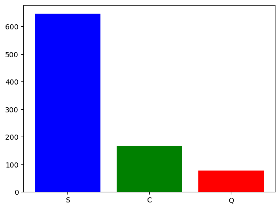

```python
embark=data['Embarked'].value_counts()
plt.bar(x=embark.index,height=embark.values,color = ['blue', 'green', 'red'])
```

From the above plot we can say that the maximum people embarked the titanic were from Southampton. The next port being Cherbourg and then Queenstown.

2. Visualizing the relationship between ticket fare paid and age of the passengers

#### **2.2 Scatter Plots**

- Scatterplot is a classic and most commonly used plot to study the relationship between two random variables
- It helps to understand the correlation between the variables

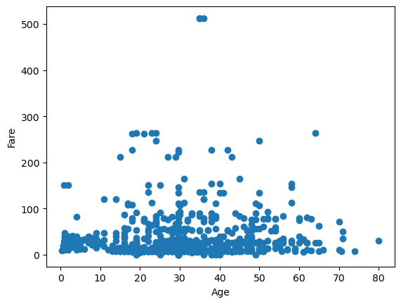

```python
age = data['Age']
fare = data['Fare']
plt.xlabel("Age")
plt.ylabel("Fare")
plt.scatter(x = age, y = fare);
```

**3. Statistical plots in matplotlib**

3. Checking the distribution of age of the passengers

#### **3.1 Histplot**

- Histoplot helps in visualizing the discrete or continuous data
- It divides the entire range of data into a series of intervals(bins) and then represents the count of values in those intervals

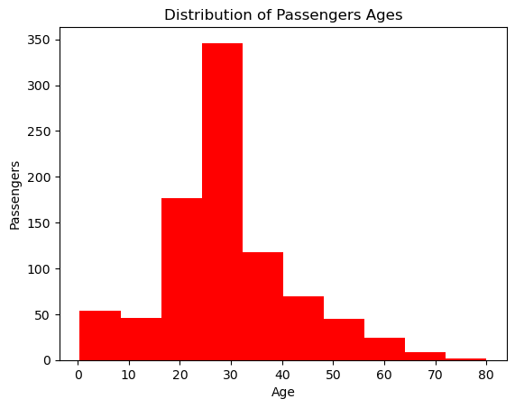

```python
plt.hist(data.Age,color='r')
plt.xlabel('Age')
plt.ylabel('Passengers')
plt.title('Distribution of Passengers Ages')
plt.show()
```

4.The percentage of the male and female passengers boarded the titanic.

#### 3.2 Pie Plot

- Pieplot is a circular statistical plot.
- It is divided into slices to represent the different categorical levels.
- It displays the percentage of observations of the different category level in a variable.

```
 [Text(-0.4919454136803954, 0.9838646807152012, 'male'),
 [Text(-0.2683338620074884, 0.5366534622082915, '64.8%'),
```

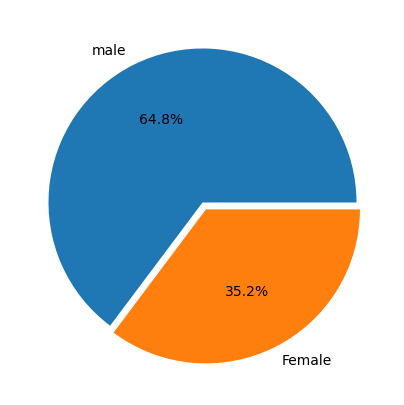

```python
plt.figure(figsize=(5,5))
values=data['Sex'].value_counts()
plt.pie(values,labels=['male','Female'],autopct='%0.1f%%',explode=[0,0.05])
```

From the Pie Plot it is clear that there were almost 65% male passengers and around 35% female passengers.

5. Checking the statistical summary of the column 'Fare'

#### 3.3 Box Plots

- Boxplot helps in visualizing the data distribution of a variable
- Box plots are important in statistical analysis because they let you see the distrubution of a data set at a glance, including outliers.

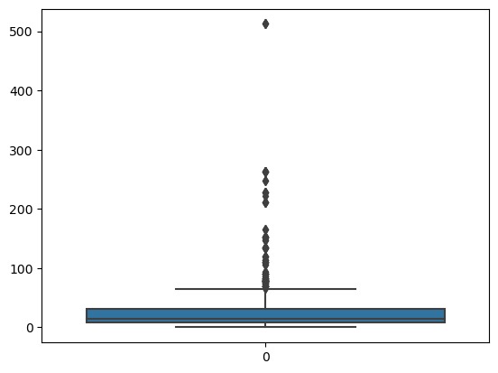

```python
sns.boxplot(data['Fare'])
```

We can pick a few key datapoints off the boxplot at a glance. The maximum fare paid by a passenger is around 500 and the minimum is 0. The median value of the fare amount is around 14. The entire distribution of column fare is around 0 to 500, and there are many data points at the high end of the scale considered as outliers.

**4. Distribution Plots in Seaborn**

6. Visualizing the column age of passengers

#### 4.1 displot

- Displot helps in understanding the variation in the data distribution.
- histplot() is the default kind of plot when displot() function is called.

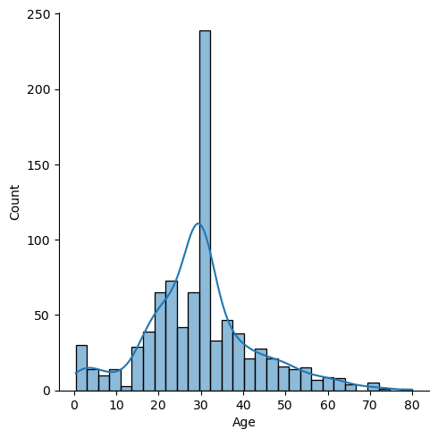

```python
sns.displot(data['Age'],kde=True)
plt.show()
```

From the above plot we can see that maximum population of the people has an age between 20-38 years. The KDE graph shows the Probability Distribution of data values as the area under the plotted curve.

**5. Categorical Plots in Seaborn**

7. Counting the number of passengers in different classes.

#### 5.1 countplot

- Countplot displays the number of observations in each categorical level using the bars.
- It is Similar to bar plot.
- The count plots can be plotted horizontally or vertically.

```python
classes_count=data['Pclass'].value_counts()
classes_count
```

```
3    491
1    216
2    184
Name: Pclass, dtype: int64
```

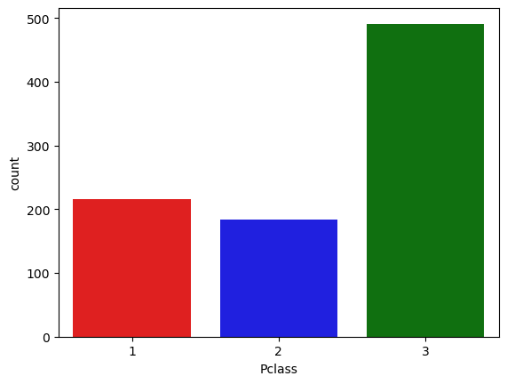

```python
sns.countplot(data,x=data['Pclass'],palette=['r','b','g'])
```

It can be clearly observed that there were almost 500 passengers from Class 3. Around 180 passengers from class 2. And almost 210 passengers from Class 1.

8. Visualize the survival rate both is males and females using catplot

#### 5.2 catplot()

- Catplot helps to visualise the categorical data much efficiently.
- It can be used for analysis between categorical features and a numerical feature.
- Can be used to plot multiple plots like count, box, strip, swarm by changing the ‘kind’ argument

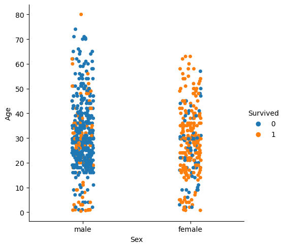

```python
sns.catplot(x = "Sex", y = "Age", data = data, kind = "strip", hue = "Survived")
plt.show()
```

From the plot we can observe more number of female passengers survived as compared to male passengers.

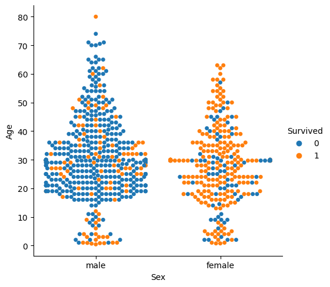

```python
sns.catplot(x = "Sex", y = "Age", data = data, kind = "swarm", hue = "Survived")
plt.show()
```

Fromt the plot it is evident that the ratio of surviving males is less than the ratio of surviving females. As for the male plot, there are more blue points and less orange points. On the other hand, for females, there are more orange points (surviving) than the blue points (not surviving).

## Number Of People Survived

```python
data.columns
```

[output not shown]

```python
data['Survived'].replace({1:'Yes',0:'No'},inplace=True)
```

```python
s=data['Survived'].value_counts()
s
```

```
No     549
Yes    342
Name: Survived, dtype: int64
```

```
 [Text(-0.3925749350994583, 1.0275626113924428, 'No'),
 [Text(-0.21413178278152267, 0.5604886971231505, '61.6%'),
```

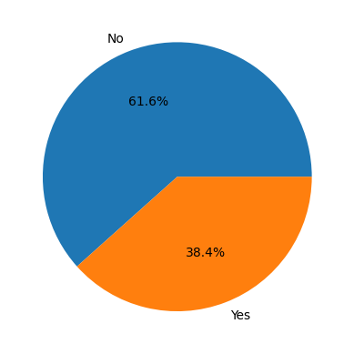

```python
plt.pie(s,labels=['No','Yes'],autopct='%0.01f%%')
```

We infer that 61.6(~62approx) people did not survive the tragedy

```python
data.head()
```

[output not shown]

```python
survived_gender = data[data['Survived'] == 1]['Sex'].value_counts()
survived_gender
```

[output not shown]

```
 [Text(-0.5931585979711493, 0.9263708100177275, 'female'),
 [Text(-0.32354105343880873, 0.5052931691005785, '68.1%'),
```

[figure not shown]

```python
survived_gender = data[data['Survived'] == 1]['Sex'].value_counts()
plt.pie(survived_gender.values, labels=survived_gender.index, autopct='%1.1f%%')
```

```python
diff_class= data[['Pclass','Survived']].value_counts()
diff_class
```

[output not shown]

```python
diff_class=data.groupby(['Pclass','Survived']).size().unstack()
diff_class
```

[output not shown]

[figure not shown]

```python
diff_class.plot(kind='bar')
plt.xlabel('Pclass')
plt.ylabel('Count')
plt.title('Counts by Pclass and Survived')
plt.show()
```

## INFERENCE:

1.We infer that 61.6(~62approx) people did not survive the tragedy

2.From the Pie Plot it is clear that there were almost 65% male passengers and around 35% female passengers.

5.Observed that there were almost 500 passengers from Class 3. Around 180 passengers from class 2.And almost 210 passengers from Class 1.

6.High class people (class 1) survived more than the other 2 classes

8.From the abovewe can say that the maximum people embarked the titanic were from Southampton. The next port being Cherbourg and then Queenstown.